# National Oceanic and Atmospheric Administration’s storm database analysis

Peer Assessent 2 submission for the Reproducible Research class.

## Submission details

| Author | Date | GitHub |
| --- | --- | --- |
| Oszkar Jozsa | February, 2015 | [[link](https://github.com/Oszkar/)] |

## Desciprtion

Your data analysis must address the following questions:

- Across the United States, which types of events (as indicated in the EVTYPE variable) are most harmful with respect to population health?
- Across the United States, which types of events have the greatest economic consequences?

Consider writing your report as if it were to be read by a government or municipal manager who might be responsible for preparing for severe weather events and will need to prioritize resources for different types of events. However, there is no need to make any specific recommendations in your report.

# Synopsys

In this report, I will investigate the most dangerous environmental disasters, based on the National Oceanic and Atmospheric Administration (NOAA) database, which was collected between 1950 and 2011.

Using simple bar charts, I will show which type of disasters cost most lives, cause most injuries and cause the most damage to properties and crops.

# Data Processing

The code below requires the data to be in the working directory. The gzipped verison of the data can be downloaded from [here](https://d396qusza40orc.cloudfront.net/repdata%2Fdata%2FStormData.csv.bz2).

## Reading the data

```r
library(data.table)
library(ggplot2)
library(stringr)
library(gridExtra)
```

Next, load the data and have a quick look at it.

```r
data <- read.csv("repdata-data-StormData.csv", header = TRUE, stringsAsFactors = FALSE)
head(data)
```

```
##   STATE__           BGN_DATE BGN_TIME TIME_ZONE COUNTY COUNTYNAME STATE
## 1       1  4/18/1950 0:00:00     0130       CST     97     MOBILE    AL
## 2       1  4/18/1950 0:00:00     0145       CST      3    BALDWIN    AL
## 3       1  2/20/1951 0:00:00     1600       CST     57    FAYETTE    AL
## 4       1   6/8/1951 0:00:00     0900       CST     89    MADISON    AL
## 5       1 11/15/1951 0:00:00     1500       CST     43    CULLMAN    AL
## 6       1 11/15/1951 0:00:00     2000       CST     77 LAUDERDALE    AL
##    EVTYPE BGN_RANGE BGN_AZI BGN_LOCATI END_DATE END_TIME COUNTY_END
## 1 TORNADO         0                                               0
## 2 TORNADO         0                                               0
## 3 TORNADO         0                                               0
## 4 TORNADO         0                                               0
## 5 TORNADO         0                                               0
## 6 TORNADO         0                                               0
##   COUNTYENDN END_RANGE END_AZI END_LOCATI LENGTH WIDTH F MAG FATALITIES
```

[output cut: 20 more lines]

```r
str(data)
```

```
## 'data.frame':    902297 obs. of  37 variables:
##  $ STATE__   : num  1 1 1 1 1 1 1 1 1 1 ...
##  $ BGN_DATE  : chr  "4/18/1950 0:00:00" "4/18/1950 0:00:00" "2/20/1951 0:00:00" "6/8/1951 0:00:00" ...
##  $ BGN_TIME  : chr  "0130" "0145" "1600" "0900" ...
##  $ TIME_ZONE : chr  "CST" "CST" "CST" "CST" ...
##  $ COUNTY    : num  97 3 57 89 43 77 9 123 125 57 ...
##  $ COUNTYNAME: chr  "MOBILE" "BALDWIN" "FAYETTE" "MADISON" ...
##  $ STATE     : chr  "AL" "AL" "AL" "AL" ...
##  $ EVTYPE    : chr  "TORNADO" "TORNADO" "TORNADO" "TORNADO" ...
##  $ BGN_RANGE : num  0 0 0 0 0 0 0 0 0 0 ...
##  $ BGN_AZI   : chr  "" "" "" "" ...
##  $ BGN_LOCATI: chr  "" "" "" "" ...
##  $ END_DATE  : chr  "" "" "" "" ...
##  $ END_TIME  : chr  "" "" "" "" ...
##  $ COUNTY_END: num  0 0 0 0 0 0 0 0 0 0 ...
```

[output cut: 23 more lines]

Finally, let’s check what kind of `EVTYPE`s are there in the data.

```r
length(unique(data$EVTYPE))
```

```
## [1] 985
```

That is almost a 1000 diffent type of events. Some of which are similar but different subcategories for example thunderstorms with different wind speeds or hails with different ice sizes. Some of them are really similar, e.g.: `heat wave`, `heat waves`, `excessive heat`, `extreme heat`. There are even typos (“thundeerstorm”, “tunderstorm”) and mislabeled data (“Summary of May 22 am”). Also, there are some categories that are the same but with different letter case (e.g.: “wind” and “WIND”).

```r
# upper case everything
data$EVTYPE <- toupper(data$EVTYPE)
# trim leading whitespace
data$EVTYPE <- str_trim(data$EVTYPE)
# replace some common subcategories / errors using grepl
data$EVTYPE[grepl("THUNDERSTORM", data$EVTYPE)] <- "THUNDERSTORM"
data$EVTYPE[grepl("THUNDEERSTORM", data$EVTYPE)] <- "THUNDERSTORM"
data$EVTYPE[grepl("TUNDERSTORM", data$EVTYPE)] <- "THUNDERSTORM"
data$EVTYPE[grepl("TSTM", data$EVTYPE)] <- "THUNDERSTORM"
data$EVTYPE[grepl("HAIL", data$EVTYPE)] <- "HAIL"
data$EVTYPE[grepl("TORNADO", data$EVTYPE)] <- "TORNADO"
data$EVTYPE[grepl("SUMMARY", data$EVTYPE)] <- "MISLABELED"
data$EVTYPE[grepl("HEAT", data$EVTYPE)] <- "HEAT"
data$EVTYPE[grepl("HIGH WIND", data$EVTYPE)] <- "HIGH WIND"
```

Let’s look at the results:

```r
length(unique(data$EVTYPE))
```

```
## [1] 601
```

A bit better but still over 600 types. Further narrowing would require deeper knowledge in environmental disasters and in the methods of collecting this data. In later graphs, we’ll only use a few of these (top20).

<sub>Note: I’ve listed the `EVTYPE`s in the appendix below so that it won’t clutter the document here.</sub>

## Preprocessing the data

```r
data$PROPDMGEXPNUM <- rep(0, nrow(data))
data$PROPDMGEXPNUM[data$PROPDMGEXP == "B"] <- 9
data$PROPDMGEXPNUM[data$PROPDMGEXP == "M"] <- 6
data$PROPDMGEXPNUM[data$PROPDMGEXP == "K"] <- 3
data$PROPDMGEXPNUM[data$PROPDMGEXP == "H"] <- 2
data$CROPDMGEXPNUM <- rep(0, nrow(data))
data$CROPDMGEXPNUM[data$CROPDMGEXP == "B"] <- 9
data$CROPDMGEXPNUM[data$CROPDMGEXP == "M"] <- 6
data$CROPDMGEXPNUM[data$CROPDMGEXP == "K"] <- 3
data$CROPDMGEXPNUM[data$CROPDMGEXP == "H"] <- 2
```

And since we’re here, let’s calculate the actual damage values.

```r
data$actualPropDmg <- data$PROPDMG * 10 ^ data$PROPDMGEXPNUM
data$actualCropDmg <- data$CROPDMG * 10 ^ data$CROPDMGEXPNUM
```

Also convert the dates from string to actual date variables

```r
data$BGN_DATE <- strptime(data$BGN_DATE, "%m/%d/%Y %H:%M:%S")
data$END_DATE <- strptime(data$END_DATE, "%m/%d/%Y %H:%M:%S")
```

## Most harmful events

Aggregate the 20 most harmful event types by both fatalities and injuries. Since fatalities are not comparable to injuries, these are handled separately.

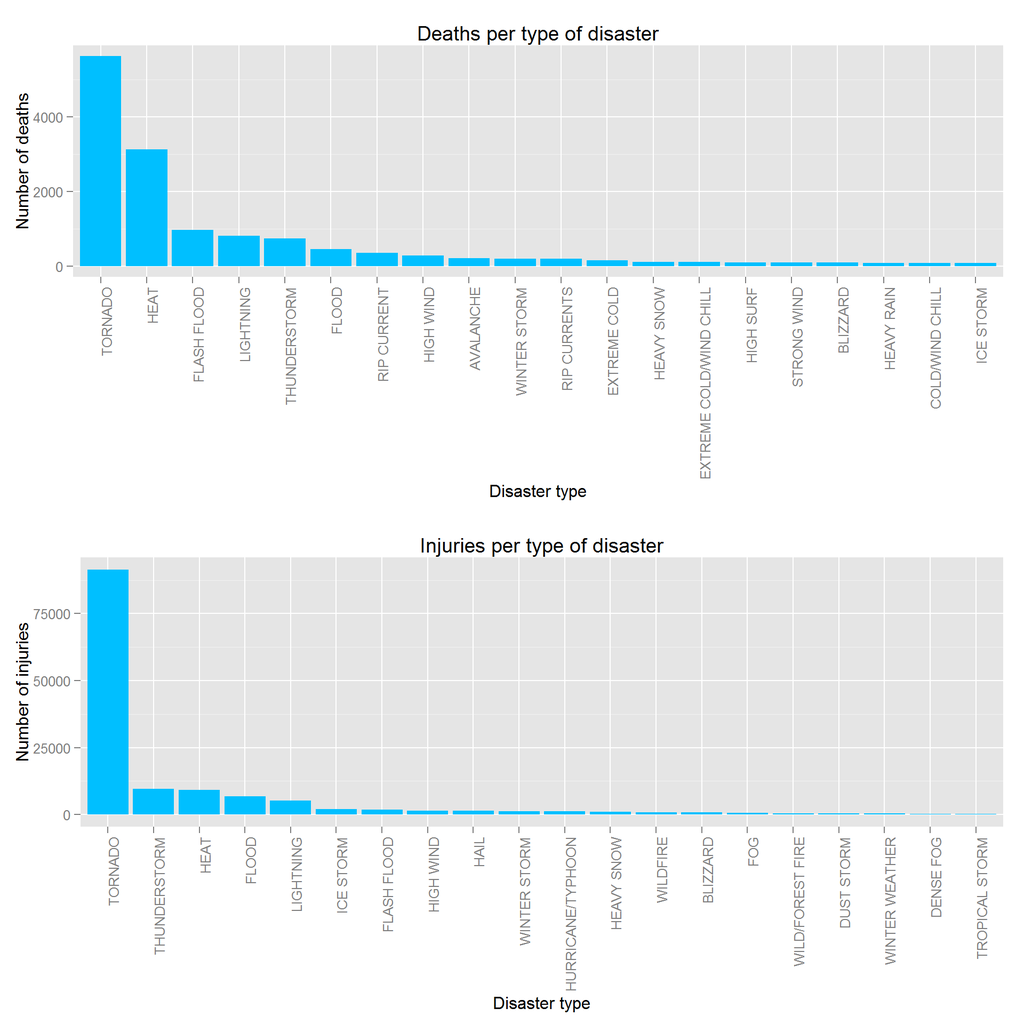

```r
fatal <- aggregate(data$FATALITIES, by = list(data$EVTYPE), "sum")
# get the first 20 (descending)
fatal <- fatal[order(-fatal$x), ][1:20,]
colnames(fatal) <- c("EvType", "No_of_fatalities")
# factorize EvType so ggplot can use it
fatal$EvType <- factor(fatal$EvType, levels = fatal$EvType)

inj <- aggregate(data$INJURIES, by = list(data$EVTYPE), "sum")
# get the first 20 (descending
inj <- inj[order(-inj$x), ][1:20,]
colnames(inj) <- c("EvType", "No_of_injuries")
# factorize EvType so ggplot can use it
inj$EvType <- factor(inj$EvType, levels = inj$EvType)

p1 <- ggplot(fatal, aes(x = EvType, y = No_of_fatalities))  +
  geom_bar(stat = "identity", fill = "deepskyblue", las = 3)  +
  theme(axis.text.x = element_text(angle = 90, hjust = 1)) +
  labs(y = "Number of deaths") +
  labs(x = "Disaster type") +
  labs(title = "Deaths per type of disaster")

p2 <- ggplot(inj, aes(x = EvType, y = No_of_injuries))  +
  geom_bar(stat = "identity", fill = "deepskyblue", las = 3)  +
  theme(axis.text.x = element_text(angle = 90, hjust = 1)) +
  labs(y = "Number of injuries") +
  labs(x = "Disaster type") +
  labs(title = "Injuries per type of disaster")

# plot the two charts using gridExtra
grid.arrange(p1, p2, ncol = 1)
```

In both cases, the tornadoes are the most harmful. Might be interestring to check how much more harmful they are than any other disasters.

Fatalities:

```r
fatal$No_of_fatalities[1]
```

```
## [1] 5636
```

```r
sum(fatal$No_of_fatalities[2:20])
```

```
## [1] 8461
```

Injuries:

```r
inj$No_of_injuries[1]
```

```
## [1] 91407
```

```r
sum(inj$No_of_injuries[2:20])
```

```
## [1] 45565
```

There are about twice as many injuries from tornadoes than from all the other disasters in the top20 most harmful ones. Also, the number of deaths is comparable, though less extreme than the injuries.

## Most costful events

We’ll do the same as before but now for cost of property and crop damage.

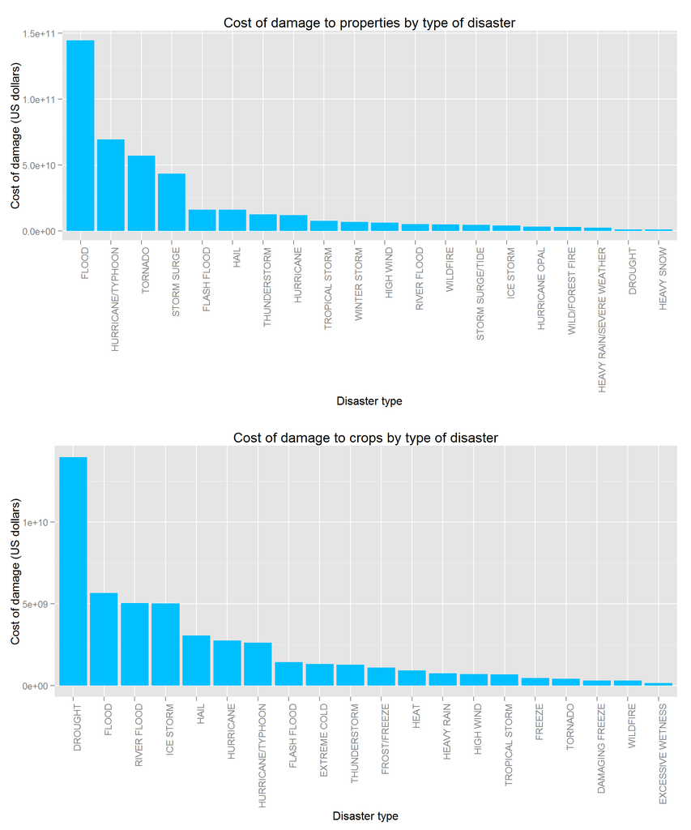

```r
prop <- aggregate(data$actualPropDmg, by = list(data$EVTYPE), "sum")
# save to overall for later use
overall <- prop
prop <- prop[order(-prop$x), ][1:20,]
colnames(prop) <- c("EvType", "Property_damage")
colnames(overall) <- c("EvType", "Damage")
prop$EvType <- factor(prop$EvType, levels = prop$EvType)

crop <- aggregate(data$actualCropDmg, by = list(data$EVTYPE), "sum")
# add up to overall
# we can do this since both is ordered by EvType
overall$Damage <- overall$Damage + crop$x
crop <- crop[order(-crop$x), ][1:20,]
colnames(crop) <- c("EvType", "Crop_damage")
crop$EvType <- factor(crop$EvType, levels = crop$EvType)


p3 <- ggplot(prop, aes(x = EvType, y = Property_damage))  +
  geom_bar(stat = "identity", fill = "deepskyblue", las = 3)  +
  theme(axis.text.x = element_text(angle = 90, hjust = 1)) +
  labs(y = "Cost of damage (US dollars)") +
  labs(x = "Disaster type") +
  labs(title = "Cost of damage to properties by type of disaster")

p4 <- ggplot(crop, aes(x = EvType, y = Crop_damage))  +
  geom_bar(stat = "identity", fill = "deepskyblue", las = 3)  +
  theme(axis.text.x = element_text(angle = 90, hjust = 1)) +
  labs(y = "Cost of damage (US dollars)") +
  labs(x = "Disaster type") +
  labs(title = "Cost of damage to crops by type of disaster")

grid.arrange(p3, p4, ncol = 1)
```

And finally let’s check the combined damage on properties and crops:

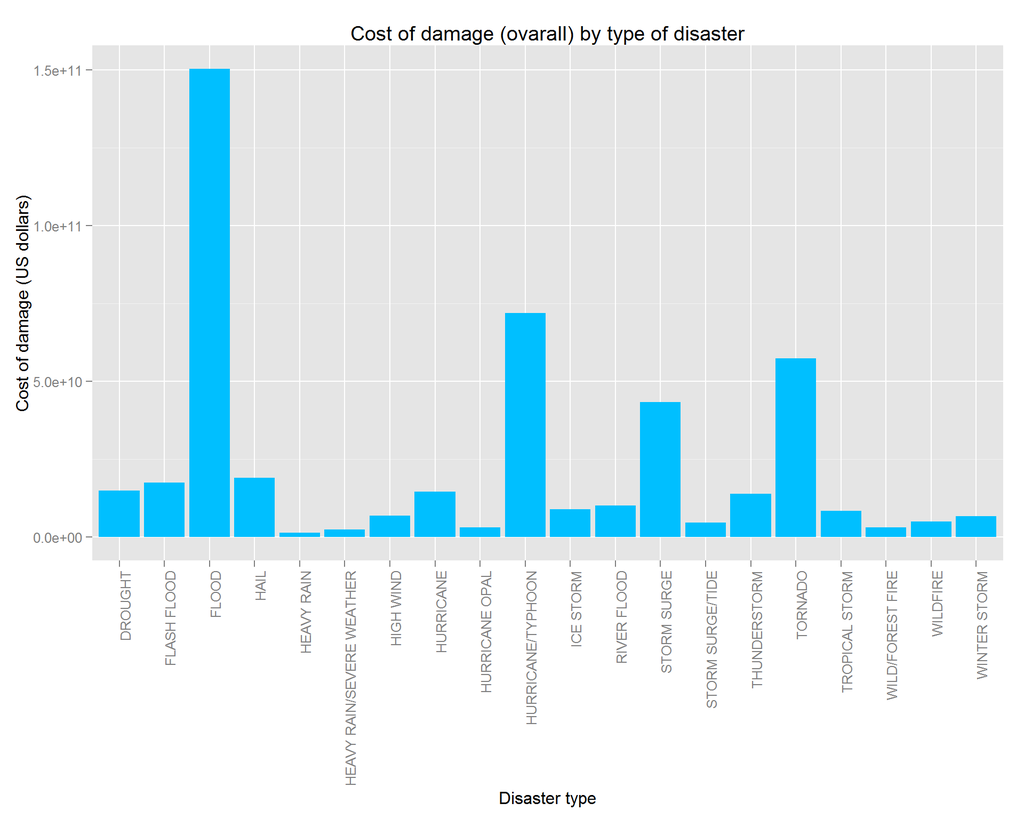

```r
overall <- overall[order(-overall$Damage), ][1:20,]

p5 <- ggplot(overall, aes(x = EvType, y = Damage))  +
  geom_bar(stat = "identity", fill = "deepskyblue", las = 3)  +
  theme(axis.text.x = element_text(angle = 90, hjust = 1)) +
  labs(y = "Cost of damage (US dollars)") +
  labs(x = "Disaster type") +
  labs(title = "Cost of damage (ovarall) by type of disaster")
p5
```

# Results

A short research showed us which environmental disasters are the most costful. In terms of injuries, tornadoes are the worst by far. In terms of property or crop damage, floods are the worst, followed by hurricanes and tornadoes. However, only in terms of crop damage, droughts are worse than floods.

# Appendix

## List of EVTYPEs

```r
unique(data$EVTYPE)
```

```
##   [1] "TORNADO"                        "THUNDERSTORM"
##   [3] "HAIL"                           "FREEZING RAIN"
##   [5] "SNOW"                           "ICE STORM/FLASH FLOOD"
##   [7] "SNOW/ICE"                       "WINTER STORM"
##   [9] "HIGH WIND"                      "RECORD COLD"
##  [11] "HURRICANE ERIN"                 "HURRICANE OPAL"
##  [13] "HEAVY RAIN"                     "LIGHTNING"
##  [15] "DENSE FOG"                      "RIP CURRENT"
##  [17] "FLASH FLOOD"                    "FLASH FLOODING"
##  [19] "FUNNEL CLOUD"                   "HEAT"
##  [21] "WIND"                           "LIGHTING"
##  [23] "HEAVY RAINS"                    "LIGHTNING AND HEAVY RAIN"
##  [25] "FUNNEL"                         "WALL CLOUD"
##  [27] "FLOODING"                       "FLOOD"
##  [29] "COLD"                           "HEAVY RAIN/LIGHTNING"
```

[output cut: 286 more lines]